# Proyecto Final

### 3.3 Relación entre contaminante y tipo de fuente

#### Dióxido de azufre

```r
SO_2 <- subset(bd_prueba, Contaminante == "SO_2")
#Filtro de los datos con el contaminante seleccionado

anova_SO_2 <- aov(Emision ~ Tipo_de_Fuente, data = SO_2)
#Anova que compara entre tipos de fuente las emisiones registradas

summary(anova_SO_2)
```

```
##                 Df    Sum Sq  Mean Sq F value   Pr(>F)
## Tipo_de_Fuente   3 159854964 53284988   16.28 5.55e-09 ***
## Residuals      124 405876593  3273198
## ---
## Signif. codes:  0 '***' 0.001 '**' 0.01 '*' 0.05 '.' 0.1 ' ' 1
## 32 observations deleted due to missingness
```

```r
#Resultado del Anova

tukey_SO_2 <- TukeyHSD(anova_SO_2)
#Entre qué tipos de fuente hay mayor o menor diferencia,


#p aj muestra el valor p ajustado, qué comparaciones son significativas
#(<0.05), con esto se pueden ver qué tipo o tipos de fuente tienen más relación con la cantidad qu eemite el contaminante. Si una o dos tipos se repiten en comparaciones con p adj <0.05, esas serán las que posean mayor relación con la emisión de la particula.
#Gráficamente
tukey_SO_2
```

```
##   Tukey multiple comparisons of means
##     95% family-wise confidence level
##
## Fit: aov(formula = Emision ~ Tipo_de_Fuente, data = SO_2)
##
## $Tipo_de_Fuente
##                                                                                  diff
## Fuentes fijas-Fuentes de área                                             2583.833467
## Fuentes móviles carreteros-Fuentes de área                                  15.281997
## Fuentes móviles que no circulan por carretera-Fuentes de área               -6.049402
## Fuentes móviles carreteros-Fuentes fijas                                 -2568.551470
## Fuentes móviles que no circulan por carretera-Fuentes fijas              -2589.882869
## Fuentes móviles que no circulan por carretera-Fuentes móviles carreteros   -21.331399
##                                                                                lwr
## Fuentes fijas-Fuentes de área                                             1405.949
## Fuentes móviles carreteros-Fuentes de área                               -1162.602
## Fuentes móviles que no circulan por carretera-Fuentes de área            -1183.934
## Fuentes móviles carreteros-Fuentes fijas                                 -3746.436
## Fuentes móviles que no circulan por carretera-Fuentes fijas              -3767.767
## Fuentes móviles que no circulan por carretera-Fuentes móviles carreteros -1199.216
##                                                                                upr
## Fuentes fijas-Fuentes de área                                             3761.718
## Fuentes móviles carreteros-Fuentes de área                                1193.166
## Fuentes móviles que no circulan por carretera-Fuentes de área             1171.835
## Fuentes móviles carreteros-Fuentes fijas                                 -1390.667
## Fuentes móviles que no circulan por carretera-Fuentes fijas              -1411.999
## Fuentes móviles que no circulan por carretera-Fuentes móviles carreteros  1156.553
##                                                                              p adj
## Fuentes fijas-Fuentes de área                                            0.0000005
## Fuentes móviles carreteros-Fuentes de área                               0.9999861
## Fuentes móviles que no circulan por carretera-Fuentes de área            0.9999991
## Fuentes móviles carreteros-Fuentes fijas                                 0.0000005
## Fuentes móviles que no circulan por carretera-Fuentes fijas              0.0000004
## Fuentes móviles que no circulan por carretera-Fuentes móviles carreteros 0.9999621
```

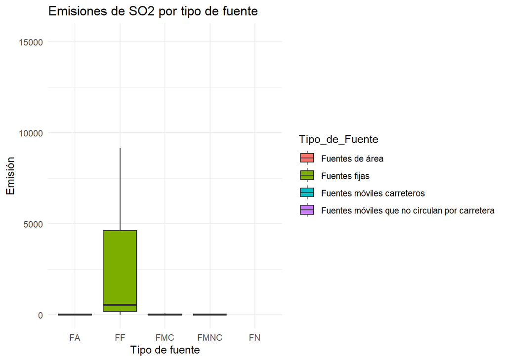

```r
ggplot(SO_2, aes(x = Tipo_de_Fuente, y = Emision, fill = Tipo_de_Fuente)) +
  geom_boxplot(outlier.shape = NA) +
  theme_minimal() +
  scale_x_discrete(labels = c(
    "Fuentes de área" = "FA",
    "Fuentes fijas" = "FF",
    "Fuentes móviles carreteros" = "FMC",
    "Fuentes móviles que no circulan por carretera" = "FMNC",
    "Fuentes naturales" = "FN")) +
  labs(title = "Emisiones de SO2 por tipo de fuente",
       y = "Emisión",
       x = "Tipo de fuente")
```

```r
#Gráfica de cajas y bigotes que compara las emisiones por tipo de fuente
```

##### Fuentes más relacionada con SO2: Fuentes Fijas

#### Monóxido de carbono

```r
CO <- subset(bd_prueba, Contaminante == "CO")
anova_CO <- aov(Emision ~ Tipo_de_Fuente, data = CO)
summary(anova_CO)
```

```
##                 Df    Sum Sq   Mean Sq F value   Pr(>F)
## Tipo_de_Fuente   3 5.481e+08 182689636   15.71 1.02e-08 ***
## Residuals      124 1.442e+09  11630704
## ---
## Signif. codes:  0 '***' 0.001 '**' 0.01 '*' 0.05 '.' 0.1 ' ' 1
## 32 observations deleted due to missingness
```

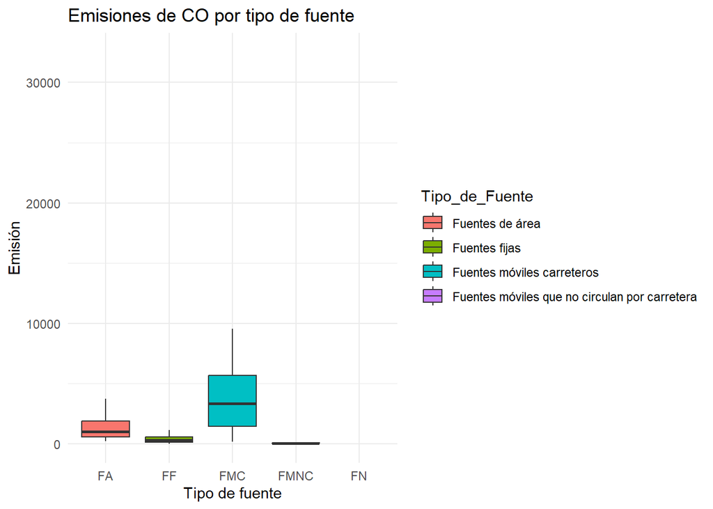

```r
tukey_CO <- TukeyHSD(anova_CO)
#tukey_CO
#Gráficamente#
ggplot(CO, aes(x = Tipo_de_Fuente, y = Emision, fill = Tipo_de_Fuente)) +
  geom_boxplot(outlier.shape = NA) +
  theme_minimal() +
  scale_x_discrete(labels = c(
    "Fuentes de área" = "FA",
    "Fuentes fijas" = "FF",
    "Fuentes móviles carreteros" = "FMC",
    "Fuentes móviles que no circulan por carretera" = "FMNC",
    "Fuentes naturales" = "FN")) +
  labs(title = "Emisiones de CO por tipo de fuente",
       y = "Emisión",
       x = "Tipo de fuente")
```

##### Fuentes más relacionada con CO: Fuentes Móviles Carreteros

#### Óxidos de nitrógeno

```r
NOx <- subset(bd_prueba, Contaminante == "NOx")
anova_NOx <- aov(Emision ~ Tipo_de_Fuente, data = NOx)
summary(anova_NOx)
```

```
##                 Df    Sum Sq  Mean Sq F value   Pr(>F)
## Tipo_de_Fuente   4  40096203 10024051   10.37 1.83e-07 ***
## Residuals      155 149905843   967134
## ---
## Signif. codes:  0 '***' 0.001 '**' 0.01 '*' 0.05 '.' 0.1 ' ' 1
```

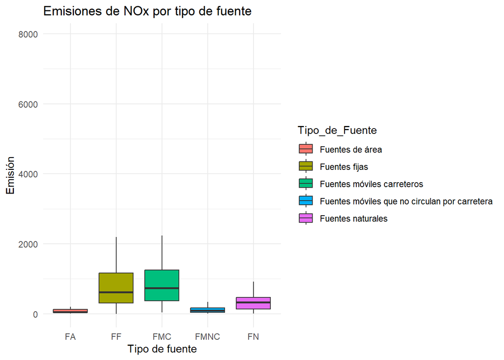

```r
tukey_NOx <- TukeyHSD(anova_NOx)
#tukey_NOx
#Gráficamente#
ggplot(NOx, aes(x = Tipo_de_Fuente, y = Emision, fill = Tipo_de_Fuente)) +
  geom_boxplot(outlier.shape = NA) +
  theme_minimal() +
  scale_x_discrete(labels = c(
    "Fuentes de área" = "FA",
    "Fuentes fijas" = "FF",
    "Fuentes móviles carreteros" = "FMC",
    "Fuentes móviles que no circulan por carretera" = "FMNC",
    "Fuentes naturales" = "FN")) +
  labs(title = "Emisiones de NOx por tipo de fuente",
       y = "Emisión",
       x = "Tipo de fuente")
```

##### Fuentes más relacionada con NOx: Fuentes Móviles Carreteros

#### Compuestos Orgánicos Volátiles

```r
COV <- subset(bd_prueba, Contaminante == "COV")
anova_COV <- aov(Emision ~ Tipo_de_Fuente, data = COV)
summary(anova_COV)
```

```
##                 Df    Sum Sq  Mean Sq F value   Pr(>F)
## Tipo_de_Fuente   4 323938272 80984568   17.32 9.16e-12 ***
## Residuals      155 724792846  4676083
## ---
## Signif. codes:  0 '***' 0.001 '**' 0.01 '*' 0.05 '.' 0.1 ' ' 1
```

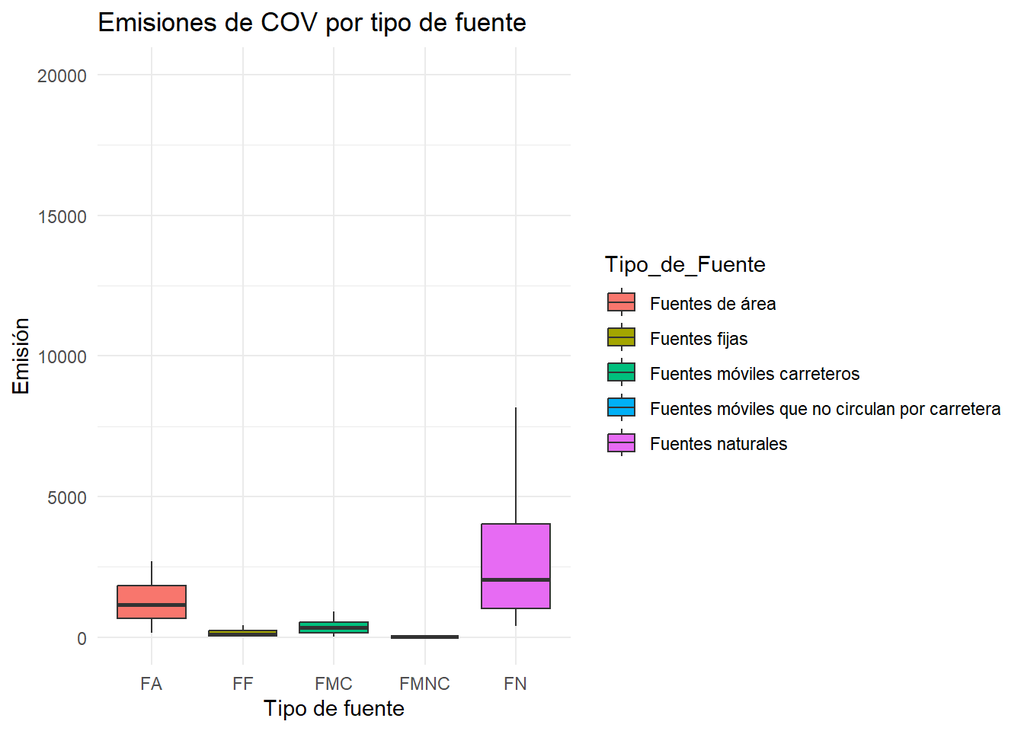

```r
tukey_COV <- TukeyHSD(anova_COV)
#tukey_COV
#Gráficamente#
ggplot(COV, aes(x = Tipo_de_Fuente, y = Emision, fill = Tipo_de_Fuente)) +
  geom_boxplot(outlier.shape = NA) +
  theme_minimal() +
  scale_x_discrete(labels = c(
    "Fuentes de área" = "FA",
    "Fuentes fijas" = "FF",
    "Fuentes móviles carreteros" = "FMC",
    "Fuentes móviles que no circulan por carretera" = "FMNC",
    "Fuentes naturales" = "FN")) +
  labs(title = "Emisiones de COV por tipo de fuente",
       y = "Emisión",
       x = "Tipo de fuente")
```

##### Fuentes más relacionada con COV: Fuentes Naturales

#### Particulas iguales o menores a 10 micras

```r
PM_010 <- subset(bd_prueba, Contaminante == "PM_010")
anova_PM_010 <- aov(Emision ~ Tipo_de_Fuente, data = PM_010)
summary(anova_PM_010)
```

```
##                 Df   Sum Sq Mean Sq F value   Pr(>F)
## Tipo_de_Fuente   3  4934086 1644695   17.43 1.67e-09 ***
## Residuals      124 11701241   94365
## ---
## Signif. codes:  0 '***' 0.001 '**' 0.01 '*' 0.05 '.' 0.1 ' ' 1
## 32 observations deleted due to missingness
```

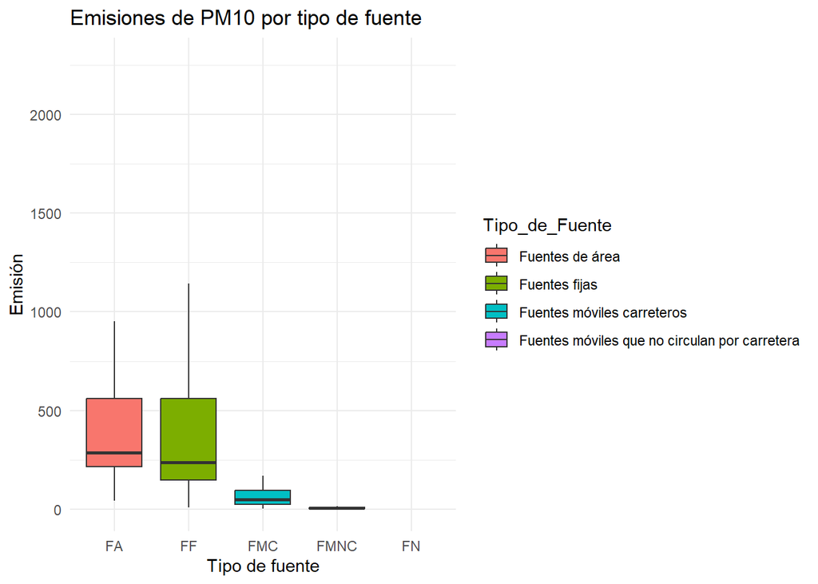

```r
tukey_PM_010 <- TukeyHSD(anova_PM_010)
#tukey_PM_010
#Gráficamente#
ggplot(PM_010, aes(x = Tipo_de_Fuente, y = Emision, fill = Tipo_de_Fuente)) +
  geom_boxplot(outlier.shape = NA) +
  theme_minimal() +
  scale_x_discrete(labels = c(
    "Fuentes de área" = "FA",
    "Fuentes fijas" = "FF",
    "Fuentes móviles carreteros" = "FMC",
    "Fuentes móviles que no circulan por carretera" = "FMNC",
    "Fuentes naturales" = "FN")) +
  labs(title = "Emisiones de PM10 por tipo de fuente",
       y = "Emisión",
       x = "Tipo de fuente")
```

##### Fuentes más relacionada con PM10: Fuentes de Área y Fuentes Fijas

#### Particulas iguales o menores a 2.5 micras

```r
PM_2_5 <- subset(bd_prueba, Contaminante == "PM_2_5")
anova_PM_2_5 <- aov(Emision ~ Tipo_de_Fuente, data = PM_2_5)
summary(anova_PM_2_5)
```

```
##                 Df  Sum Sq Mean Sq F value   Pr(>F)
## Tipo_de_Fuente   3 1544419  514806      18 9.21e-10 ***
## Residuals      124 3545597   28594
## ---
## Signif. codes:  0 '***' 0.001 '**' 0.01 '*' 0.05 '.' 0.1 ' ' 1
## 32 observations deleted due to missingness
```

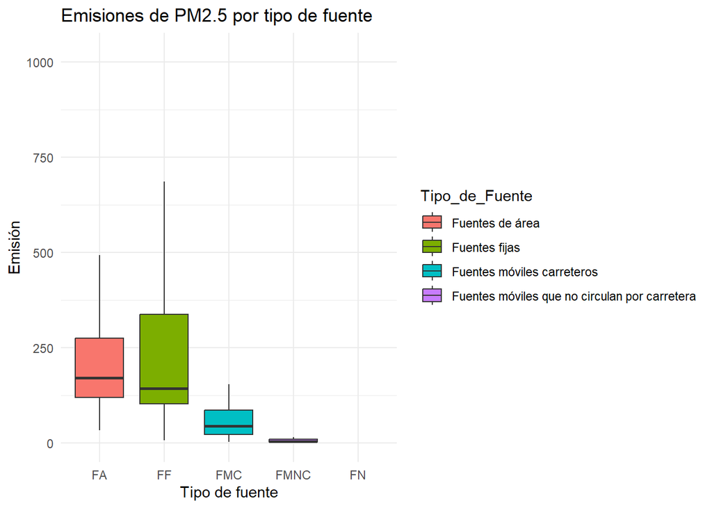

```r
tukey_PM_2_5 <- TukeyHSD(anova_PM_2_5)
#tukey_PM_2_5
#Gráficamente#
ggplot(PM_2_5, aes(x = Tipo_de_Fuente, y = Emision, fill = Tipo_de_Fuente)) +
  geom_boxplot(outlier.shape = NA) +
  theme_minimal() +
  scale_x_discrete(labels = c(
    "Fuentes de área" = "FA",
    "Fuentes fijas" = "FF",
    "Fuentes móviles carreteros" = "FMC",
    "Fuentes móviles que no circulan por carretera" = "FMNC",
    "Fuentes naturales" = "FN")) +
  labs(title = "Emisiones de PM2.5 por tipo de fuente",
       y = "Emisión",
       x = "Tipo de fuente")
```

#### Amoniaco

```r
NH_3 <- subset(bd_prueba, Contaminante == "NH_3")
anova_NH_3 <- aov(Emision ~ Tipo_de_Fuente, data = NH_3)
summary(anova_NH_3)
```

```
##                 Df   Sum Sq Mean Sq F value   Pr(>F)
## Tipo_de_Fuente   3 10955528 3651843   21.92 1.87e-11 ***
## Residuals      124 20658684  166602
## ---
## Signif. codes:  0 '***' 0.001 '**' 0.01 '*' 0.05 '.' 0.1 ' ' 1
## 32 observations deleted due to missingness
```

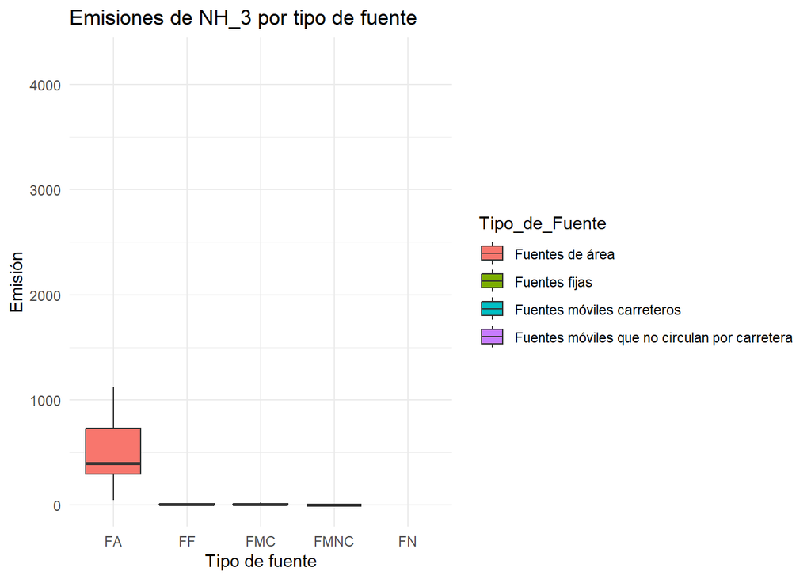

```r
tukey_NH_3 <- TukeyHSD(anova_NH_3)
#tukey_NH_3
#Gráficamente#
ggplot(NH_3, aes(x = Tipo_de_Fuente, y = Emision, fill = Tipo_de_Fuente)) +
  geom_boxplot(outlier.shape = NA) +
  theme_minimal() +
  scale_x_discrete(labels = c(
    "Fuentes de área" = "FA",
    "Fuentes fijas" = "FF",
    "Fuentes móviles carreteros" = "FMC",
    "Fuentes móviles que no circulan por carretera" = "FMNC",
    "Fuentes naturales" = "FN")) +
  labs(title = "Emisiones de NH_3 por tipo de fuente",
       y = "Emisión",
       x = "Tipo de fuente")
```

##### Fuentes más relacionada con NH3, Fuentes de Área

### Gráfico completo

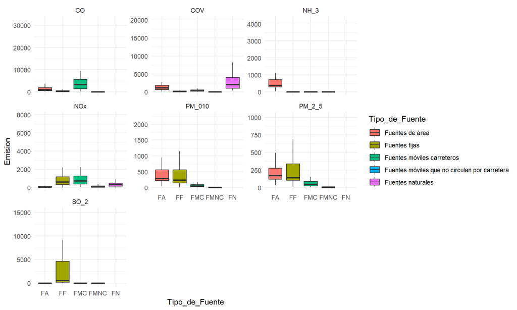

```r
ggplot(bd_prueba, aes(x = Tipo_de_Fuente, y = Emision, fill = Tipo_de_Fuente)) +
  geom_boxplot(outlier.shape = NA) +
  facet_wrap(~Contaminante, scales = "free_y") +
  theme_minimal() +
  scale_x_discrete(labels = c(
    "Fuentes de área" = "FA",
    "Fuentes fijas" = "FF",
    "Fuentes móviles carreteros" = "FMC",
    "Fuentes móviles que no circulan por carretera" = "FMNC",
    "Fuentes naturales" = "FN"))
```

#### Con esto podemos resolver la 1° pregunta: ¿Qué tipos de fuentes contribuyeron más a la emisión de cada tipo de contaminate? Pues cada una o más emiten ciertos contaminantes en mayor medida que otros, por ejemplo, las fuentes naturales emiten más COV que las demás, mientras que el Amoniaco (NH3) es emitido principalmente por medio de fuentes de área.

### 3.4 Relación entre estados y contaminantes

### 3.4.1 Regiones

```r
#Creamos una nueva columna (region) asignando a los estados correspondientes
co$region <- case_when(
  co$Entidad_federativa %in% c("Baja California", "Sonora", "Chihuahua", "Durango", "Sinaloa", "Baja California Sur") ~ "Noroeste",
  co$Entidad_federativa %in% c("Coahuila", "Nuevo León", "Tamaulipas") ~ "Noreste",
  co$Entidad_federativa %in% c("Nayarit", "Jalisco", "Colima", "Michoacán") ~ "Occidente",
  co$Entidad_federativa %in% c("Zacatecas", "Aguascalientes", "San Luis Potosí", "Guanajuato") ~ "Bajío",
  co$Entidad_federativa %in% c("Querétaro", "Hidalgo", "Tlaxcala", "Puebla", "Ciudad de México","México", "Morelos") ~ "Centro",
  co$Entidad_federativa %in% c("Guerrero", "Oaxaca", "Chiapas") ~ "Sur",
  co$Entidad_federativa %in% c("Tabasco", "Campeche", "Yucatán","Quintana Roo","Veracruz") ~ "Sureste",
  TRUE ~ "Otra"
)
```

### 3.4.2 PCA

```r
#Para el PCA, vamos a usar los datos de las las columnas 2 - 8, que corresponden a los contamiantes
pca_data <- co %>% select(2:8)

#Se guarda el PCA, asegurando que todos tengan una escala cercana para no estar afectados por la variación
pca_result <- prcomp(pca_data, scale. = TRUE)

#Podemos ver la Desviacipon estandar y las proporciones que explican cada Componentes, así com ola acumulativa
summary(pca_result)
```

```
## Importance of components:
##                           PC1    PC2    PC3     PC4     PC5     PC6     PC7
## Standard deviation     2.0232 1.0474 0.8649 0.75273 0.60824 0.33187 0.12257
## Proportion of Variance 0.5847 0.1567 0.1069 0.08094 0.05285 0.01573 0.00215
## Cumulative Proportion  0.5847 0.7415 0.8483 0.92927 0.98212 0.99785 1.00000
```

```r
#Los dos primeros componentes ya explican ~74%, y con el 3°, ~84%
```

### Gráficamente

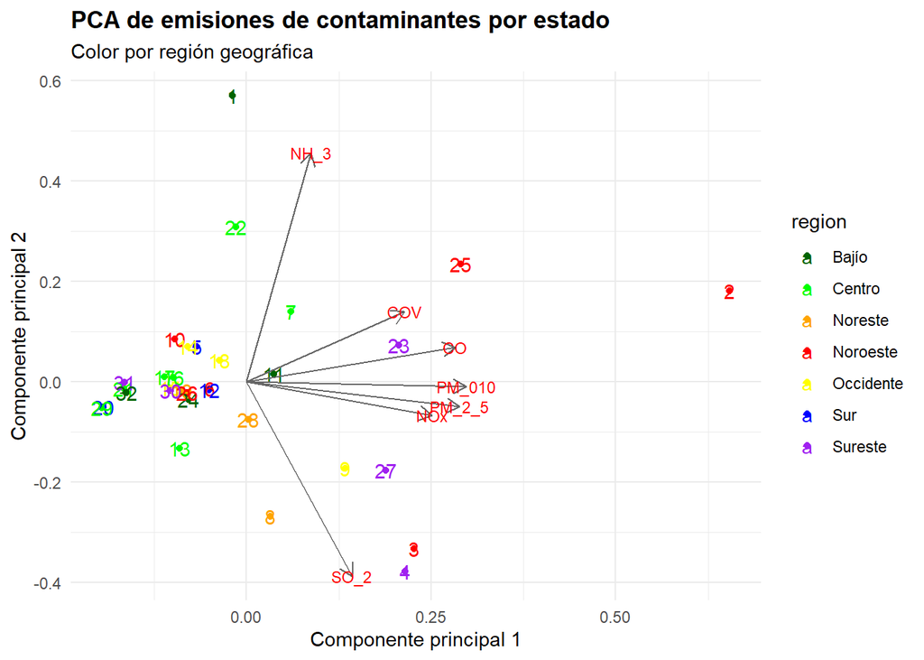

```r
autoplot(pca_result,
         data = co,
         colour = "region",      # colores por región
         label = TRUE,           # mostrar nombre del estado
         loadings = TRUE,        # mostrar vectores de contaminantes
         loadings.label = TRUE,  # mostrar nombres de contaminantes
         loadings.label.size = 3,
         loadings.colour = "gray40") +
  scale_color_manual(values = c("Noroeste" = "red",
                                "Noreste" = "orange",
                                "Occidente" = "yellow",
                                "Bajío" = "darkgreen",
                                "Centro" = "green",
                                "Sur" = "blue",
                                "Sureste" = "purple"
                                )) +
  theme_minimal() +
  labs(title = "PCA de emisiones de contaminantes por estado",
       subtitle = "Color por región geográfica",
       x = "Componente principal 1",
       y = "Componente principal 2") +
  theme(plot.title = element_text(face = "bold"),
        legend.position = "right")
```

```r
#Esta gráfica muestra la influencia de los dos primeros componentes principales, y muestra por color a qué región pertenecen
```

### Se pueden responder las otras preguntas: ¿Cómo se agrupan los estados de México según su perfil de emisiones de distintos contaminantes, y qué contaminantes explican esas diferencias?

### Grupos claros no son visibles, aunque la mayoría está negativamente relacionada a las emisiones de PM 10, PM 2.5, Óxidos de nitrógeno y Monóxido de carbono. Mientras que existen particularidades, pues tanto en los mapas como en la anterior gráfica, hay estados que emiten ciertos contaminantes más que otros: Aguascalientes (1) con el Amoniaco, Campeche(4) y Baja California Sur(3) con el Dióxido de Azufre (SO2), y Baja California (2) con el Monóxido de Carbono.

## Conclusión

### Sí existen diferencias entre la emisión de contaminantes en México, habiendo estaddos que emiten determinados contamiantes más que otros, y al mismo tiempo, las fuentes de esos contaminantes tambien presentan diferencias en la cantidad que emiten de cada uno de las particulas registradas.

### Para una mejor interpretación del porqué de esta dinámica, se podría añadir, por ejemplo, qué actividad económica se realiza con mayor intensidad en cada estado. Pudiendo ser una mejor explicación que la región en la que se encuentran.